# DATS 6101 - Midterm

Name: Snehitha Tadapaneni, Sai Rachana Kandikattu, Amrutha Jayachandradhara, Wilona Nguyen, Pramod Krishnachari

2024-10-28

# Introduction

Our research focuses on performing Exploratory Data Analysis (EDA) on Google Play Store apps to uncover patterns, trends, and insights regarding app characteristics, user behavior, and installation patterns. We are trying to see how app popularity, defined as the number of installs with high reviews and ratings, is impacted by categories, last updated, app sizes, version, and other factors.

# Smart Question

“What is the impact of content rating, required Android version, app category, size, and pricing on predicting app success in terms of positive ratings and high user reviews, as well as the number of installs, using data from Google Play Store apps from 2010 to 2018?”

> *Specific*: The question clearly defines the variables (content rating, required Android version, app category, size, pricing) and the outcomes (positive ratings, high user reviews, number of installs).

> *Measurable*: The outcomes (positive ratings, high user reviews, number of installs) are quantifiable.

> *Achievable*: Given the availability of Google Play Store data from 2010 to 2018, the analysis is feasible.

> *Relevant*: The question addresses a significant issue in the app development and marketing industry: predicting app success.

> *Time-specific*: The timeframe (2010-2018) is clearly defined.

# Data Preparation and Cleaning

```r
#Loading the Dataset
data_apps <- data.frame(read.csv("googleplaystore.csv"))
```

```r
#Checking the structure of the data
str(data_apps)
```

```
## 'data.frame':    10841 obs. of  13 variables:
##  $ App           : chr  "Photo Editor & Candy Camera & Grid & ScrapBook" "Coloring book moana" "U Launcher Lite – FREE Live Cool Themes, Hide Apps" "Sketch - Draw & Paint" ...
##  $ Category      : chr  "ART_AND_DESIGN" "ART_AND_DESIGN" "ART_AND_DESIGN" "ART_AND_DESIGN" ...
##  $ Rating        : num  4.1 3.9 4.7 4.5 4.3 4.4 3.8 4.1 4.4 4.7 ...
##  $ Reviews       : chr  "159" "967" "87510" "215644" ...
##  $ Size          : chr  "19M" "14M" "8.7M" "25M" ...
##  $ Installs      : chr  "10,000+" "500,000+" "5,000,000+" "50,000,000+" ...
##  $ Type          : chr  "Free" "Free" "Free" "Free" ...
##  $ Price         : chr  "0" "0" "0" "0" ...
##  $ Content.Rating: chr  "Everyone" "Everyone" "Everyone" "Teen" ...
##  $ Genres        : chr  "Art & Design" "Art & Design;Pretend Play" "Art & Design" "Art & Design" ...
##  $ Last.Updated  : chr  "January 7, 2018" "January 15, 2018" "August 1, 2018" "June 8, 2018" ...
##  $ Current.Ver   : chr  "1.0.0" "2.0.0" "1.2.4" "Varies with device" ...
##  $ Android.Ver   : chr  "4.0.3 and up" "4.0.3 and up" "4.0.3 and up" "4.2 and up" ...
```

```r
#First 5 rows of the dataset
head(data_apps)
```

```
##                                                  App       Category Rating
## 1     Photo Editor & Candy Camera & Grid & ScrapBook ART_AND_DESIGN    4.1
## 2                                Coloring book moana ART_AND_DESIGN    3.9
## 3 U Launcher Lite – FREE Live Cool Themes, Hide Apps ART_AND_DESIGN    4.7
## 4                              Sketch - Draw & Paint ART_AND_DESIGN    4.5
## 5              Pixel Draw - Number Art Coloring Book ART_AND_DESIGN    4.3
## 6                         Paper flowers instructions ART_AND_DESIGN    4.4
##   Reviews Size    Installs Type Price Content.Rating                    Genres
## 1     159  19M     10,000+ Free     0       Everyone              Art & Design
## 2     967  14M    500,000+ Free     0       Everyone Art & Design;Pretend Play
## 3   87510 8.7M  5,000,000+ Free     0       Everyone              Art & Design
## 4  215644  25M 50,000,000+ Free     0           Teen              Art & Design
## 5     967 2.8M    100,000+ Free     0       Everyone   Art & Design;Creativity
## 6     167 5.6M     50,000+ Free     0       Everyone              Art & Design
##       Last.Updated        Current.Ver  Android.Ver
## 1  January 7, 2018              1.0.0 4.0.3 and up
## 2 January 15, 2018              2.0.0 4.0.3 and up
## 3   August 1, 2018              1.2.4 4.0.3 and up
## 4     June 8, 2018 Varies with device   4.2 and up
## 5    June 20, 2018                1.1   4.4 and up
## 6   March 26, 2017                1.0   2.3 and up
```

#### Description of the App Dataset Columns

1. App: The name of the application, represented as a character string.
2. Category: The main category of the app, such as “ART_AND_DESIGN,” represented as a character string.
3. Rating: The average user rating of the app, recorded as a numeric value.
4. Reviews: The total number of user reviews for the app, shown as a character string.
5. Size: The size of the application, represented as a character string.
6. Installs: The approximate number of installations for the app, stored as a character string.
7. Type: Indicates whether the app is free or paid, represented as a character string.
8. Price: The price of the app, stored as a character string. Free apps are listed as “0,” while paid apps have a dollar amount.
9. Content.Rating: The target age group for the app, represented as a character string.
10. Genres: The genre(s) of the app.
11. Last.Updated: The date of the app’s last update, stored as a character string.
12. Current.Ver: The current version of the app, represented as a character string.
13. Android.Ver: The minimum Android version required to run the app, stored as a character string.

## Apps

```r
# Checking the type of the App
typeof(data_apps$App)
```

```
## [1] "character"
```

#### Checking for duplicated apps and removing

```r
#Display all the duplicated Apps
duplicate_apps <- aggregate(App ~ ., data = data_apps, FUN = length)
duplicate_apps <- duplicate_apps[duplicate_apps$App > 1, ]
duplicate_apps <- duplicate_apps[order(-duplicate_apps$App), ]

#View(duplicate_apps)
#print(duplicate_apps)

print(paste("Number of duplicated Apps:",nrow(duplicate_apps)))
```

```
## [1] "Number of duplicated Apps: 404"
```

```r
#Removing Na values and duplicates
data_clean <- data_apps[!is.na(data_apps$App), ]
data_clean <- data_clean[!duplicated(data_clean$App), ]

#(After removing the duplicates) Unique values
unique_apps <- length(unique(data_clean$App))
print(paste("Number of unique apps after removing the duplicates:", unique_apps))
```

```
## [1] "Number of unique apps after removing the duplicates: 9660"
```

Duplicate App Analysis:

- 404 apps were repeated either twice or thrice.
- After removing duplicates, the dataset now contains 9660 unique apps.
- Total duplicates removed: 1181 apps.

#### After dropping duplicate

```r
str(data_clean$App)
```

```
##  chr [1:9660] "Photo Editor & Candy Camera & Grid & ScrapBook" ...
```

## Price

```r
typeof(data_apps$Price)
```

```
## [1] "character"
```

#### Convertion of Price to numerical

There is ‘$’ present after each price of the App. Check and remove before conversion.

```r
#To check if there is dollar symbol present
#data_clean$Price[]
```

```r
# Remove dollar symbols and convert to numeric
data_clean$Price <- as.numeric(gsub("\\$", "", data_clean$Price))
```

```r
#Recheck for dollar symbol
#data_clean$Price[]
```

All the dollar symbols are removed succesfully.

```r
# Summary statistics for price
summary(data_clean$Price)
```

```
##    Min. 1st Qu.  Median    Mean 3rd Qu.    Max.    NA's
##   0.000   0.000   0.000   1.099   0.000 400.000       1
```

From the unique_df, there is a missing value present in the Price column. Let’s handle it!

#### Checking for missing values in Price

```r
missing_na <- is.na(data_clean$Price)
missing_blank <- data_clean$Price == ""

sum(missing_na)
```

```
## [1] 1
```

```r
sum(missing_blank, na.rm = TRUE)
```

```
## [1] 0
```

```r
# Remove row where Price is NA or blank
data_clean <- data_clean[!is.na(data_clean$Price) & data_clean$Price != "", ]
```

Have removed one row #10473 which app does not have a category nameas it is not relevant to our analysis.

```r
#Recheck for missing values
summary(data_clean$Price)
```

```
##    Min. 1st Qu.  Median    Mean 3rd Qu.    Max.
##   0.000   0.000   0.000   1.099   0.000 400.000
```

##### Missing values removed succesfully. (Price)

## Type

```r
#Checking the type of Type variable
table(data_clean$Type)
```

```
##
## Free Paid
## 8902  756
```

From the price column, we can see 8903 apps are free but it is misread somewhere in the Type column. So lets check!

```r
#Checking for Missing values
print(paste("Missing values:",sum(is.na(data_clean$Type))))
```

```
## [1] "Missing values: 0"
```

```r
data_clean[is.na(data_clean$Type), ]
```

```
##  [1] App            Category       Rating         Reviews        Size
##  [6] Installs       Type           Price          Content.Rating Genres
## [11] Last.Updated   Current.Ver    Android.Ver
## <0 rows> (or 0-length row.names)
```

```r
# Replace NaN or missing values in the Type column with "Free"
data_clean$Type[is.na(data_clean$Type)] <- "Free"
```

## Size

```r
# Checking the type of the Size
typeof(data_apps$Size)
```

```
## [1] "character"
```

#### Replacing Misiing values with the mean (Size)

```r
# Replace "Varies with Device" in the Size column with NA
data_clean$Size[data_clean$Size == "Varies with device"] <- NA
data_clean <- data_clean[!grepl("\\+", data_clean$Size), ]
data_clean$Size <- ifelse(grepl("k", data_clean$Size),
                          as.numeric(gsub("k", "", data_clean$Size)) *
0.001,  # Convert "K" to MB
                          as.numeric(gsub("M", "", data_clean$Size)))
# Remove "M" for megabytes
# Calculate and display the mean size for each category in the 'Type' column
mean_size_by_type <- tapply(data_clean$Size, data_clean$Category,
mean, na.rm = TRUE)
print(mean_size_by_type)
```

```
##      ART_AND_DESIGN   AUTO_AND_VEHICLES              BEAUTY BOOKS_AND_REFERENCE
##           12.370968           20.037147           13.795745           13.134701
##            BUSINESS              COMICS       COMMUNICATION              DATING
##           13.867194           13.794959           11.307430           15.661119
##           EDUCATION       ENTERTAINMENT              EVENTS              FAMILY
##           19.057101           23.043750           13.963754           27.187988
##             FINANCE      FOOD_AND_DRINK                GAME  HEALTH_AND_FITNESS
##           17.368127           20.494318           41.866609           20.669707
##      HOUSE_AND_HOME  LIBRARIES_AND_DEMO           LIFESTYLE MAPS_AND_NAVIGATION
##           15.970258           10.602883           14.844916           16.368121
##             MEDICAL  NEWS_AND_MAGAZINES           PARENTING     PERSONALIZATION
##           19.189399           12.470189           22.512963           11.224624
##         PHOTOGRAPHY        PRODUCTIVITY            SHOPPING              SOCIAL
##           15.666158           12.342505           15.491435           15.984090
##              SPORTS               TOOLS    TRAVEL_AND_LOCAL       VIDEO_PLAYERS
##           24.058361            8.782837           24.204410           15.792756
##             WEATHER
##           12.680036
```

```r
# Loop through each row and replace NA values in the Size column with the mean size of the corresponding category
data_clean$Size <- ifelse(
  is.na(data_clean$Size),  # Check if Size is NA
  round(mean_size_by_type[data_clean$Category], 1),  # Replace with the mean size based on the Category
  data_clean$Size  # Keep the original size if it's not NA
)
```

## Installs

####Remove the ‘+’ sign, Remove the commas, Convert to numeric

```r
#clean installations
clean_installs <- function(Installs) {
  Installs <- gsub("\\+", "", Installs)
  Installs <- gsub(",", "", Installs)
  return(as.numeric(Installs))
}

data_clean$Installs <- sapply(data_clean$Installs, clean_installs)

nan_rows <- sapply(data_clean[, c("Size", "Installs")], function(x) any(is.nan(x)))

# Display only rows that contain NaN in either Size or Installs
data_clean[,nan_rows]
```

```
## data frame with 0 columns and 9659 rows
```

```r
datatable((data_clean), options = list(scrollX = TRUE ))
```

|  | App | Category | Rating | Reviews | Size | Installs | Type | Price | Content.Rating | Genres | Last.Updated | Current.Ver | Android.Ver |
| --- | --- | --- | --- | --- | --- | --- | --- | --- | --- | --- | --- | --- | --- |
| 1 | Photo Editor &amp; Candy Camera &amp; Grid &amp; ScrapBook | ART_AND_DESIGN | 4.1 | 159 | 19 | 10000 | Free | 0 | Everyone | Art &amp; Design | January 7, 2018 | 1.0.0 | 4.0.3 and up |
| 2 | Coloring book moana | ART_AND_DESIGN | 3.9 | 967 | 14 | 500000 | Free | 0 | Everyone | Art &amp; Design;Pretend Play | January 15, 2018 | 2.0.0 | 4.0.3 and up |
| 3 | U Launcher Lite – FREE Live Cool Themes, Hide Apps | ART_AND_DESIGN | 4.7 | 87510 | 8.7 | 5000000 | Free | 0 | Everyone | Art &amp; Design | August 1, 2018 | 1.2.4 | 4.0.3 and up |
| 4 | Sketch - Draw &amp; Paint | ART_AND_DESIGN | 4.5 | 215644 | 25 | 50000000 | Free | 0 | Teen | Art &amp; Design | June 8, 2018 | Varies with device | 4.2 and up |
| 5 | Pixel Draw - Number Art Coloring Book | ART_AND_DESIGN | 4.3 | 967 | 2.8 | 100000 | Free | 0 | Everyone | Art &amp; Design;Creativity | June 20, 2018 | 1.1 | 4.4 and up |
| 6 | Paper flowers instructions | ART_AND_DESIGN | 4.4 | 167 | 5.6 | 50000 | Free | 0 | Everyone | Art &amp; Design | March 26, 2017 | 1.0 | 2.3 and up |
| 7 | Smoke Effect Photo Maker - Smoke Editor | ART_AND_DESIGN | 3.8 | 178 | 19 | 50000 | Free | 0 | Everyone | Art &amp; Design | April 26, 2018 | 1.1 | 4.0.3 and up |
| 8 | Infinite Painter | ART_AND_DESIGN | 4.1 | 36815 | 29 | 1000000 | Free | 0 | Everyone | Art &amp; Design | June 14, 2018 | 6.1.61.1 | 4.2 and up |
| 9 | Garden Coloring Book | ART_AND_DESIGN | 4.4 | 13791 | 33 | 1000000 | Free | 0 | Everyone | Art &amp; Design | September 20, 2017 | 2.9.2 | 3.0 and up |
| 10 | Kids Paint Free - Drawing Fun | ART_AND_DESIGN | 4.7 | 121 | 3.1 | 10000 | Free | 0 | Everyone | Art &amp; Design;Creativity | July 3, 2018 | 2.8 | 4.0.3 and up |

[output cut: 9649 more lines]

#### Display the unique values

```r
data_clean <- data_clean %>%
  mutate(Rating = ifelse(is.na(Rating), mean(Rating, na.rm = TRUE), Rating))

# Identify the unique values in the 'Installs' column
unique_values <- unique(data_clean$Installs)

# Display the unique values
print(unique_values)
```

```
##  [1] 1e+04 5e+05 5e+06 5e+07 1e+05 5e+04 1e+06 1e+07 5e+03 1e+08 1e+09 1e+03
## [13] 5e+08 5e+01 1e+02 5e+02 1e+01 1e+00 5e+00 0e+00
```

```r
# Function to convert the installs to numeric
convert_to_numeric <- function(x) {
  # Remove non-numeric characters and convert to numeric
  as.numeric(gsub("[^0-9]", "", x)) * 10^(length(gregexpr(",", x)[[1]]) - 1)
}

# Sort unique values based on the custom numeric conversion
sorted_values <- unique_values[order(sapply(unique_values, convert_to_numeric))]
```

## Rating and Reviews

```r
# Checking the type of the Rating
typeof(data_clean$Rating)
```

```
## [1] "double"
```

```r
# Checking the type of the Reviews
typeof(data_clean$Reviews)
```

```
## [1] "character"
```

#### Checking the format of Rating and Reviews

```
##  chr [1:9659] "159" "967" "87510" "215644" "967" "167" "178" "36815" ...
```

```
##  num [1:9659] 4.1 3.9 4.7 4.5 4.3 4.4 3.8 4.1 4.4 4.7 ...
```

As we can see the Review column is in string format which could be converted into int for more insights.

#### Change the column reviews from Str to int

```
## 'data.frame':    9659 obs. of  13 variables:
##  $ App           : chr  "Photo Editor & Candy Camera & Grid & ScrapBook" "Coloring book moana" "U Launcher Lite – FREE Live Cool Themes, Hide Apps" "Sketch - Draw & Paint" ...
##  $ Category      : chr  "ART_AND_DESIGN" "ART_AND_DESIGN" "ART_AND_DESIGN" "ART_AND_DESIGN" ...
##  $ Rating        : num  4.1 3.9 4.7 4.5 4.3 4.4 3.8 4.1 4.4 4.7 ...
##  $ Reviews       : num  159 967 87510 215644 967 ...
##  $ Size          : num  19 14 8.7 25 2.8 5.6 19 29 33 3.1 ...
##  $ Installs      : num  1e+04 5e+05 5e+06 5e+07 1e+05 5e+04 5e+04 1e+06 1e+06 1e+04 ...
##  $ Type          : chr  "Free" "Free" "Free" "Free" ...
##  $ Price         : num  0 0 0 0 0 0 0 0 0 0 ...
##  $ Content.Rating: chr  "Everyone" "Everyone" "Everyone" "Teen" ...
##  $ Genres        : chr  "Art & Design" "Art & Design;Pretend Play" "Art & Design" "Art & Design" ...
##  $ Last.Updated  : chr  "January 7, 2018" "January 15, 2018" "August 1, 2018" "June 8, 2018" ...
##  $ Current.Ver   : chr  "1.0.0" "2.0.0" "1.2.4" "Varies with device" ...
##  $ Android.Ver   : chr  "4.0.3 and up" "4.0.3 and up" "4.0.3 and up" "4.2 and up" ...
```

Table: Statistics summary.

|  | App | Category | Rating | Reviews | Size | Installs | Type | Price | Content.Rating | Genres | Last.Updated | Current.Ver | Android.Ver |
| --- | --- | --- | --- | --- | --- | --- | --- | --- | --- | --- | --- | --- | --- |
| Min | Length:9659 | Length:9659 | Min. :1.000 | Min. : 0 | Min. : 0.0085 | Min. :0.000e+00 | Length:9659 | Min. : 0.000 | Length:9659 | Length:9659 | Length:9659 | Length:9659 | Length:9659 |
| Q1 | Class :character | Class :character | 1st Qu.:4.000 | 1st Qu.: 25 | 1st Qu.: 5.3000 | 1st Qu.:1.000e+03 | Class :character | 1st Qu.: 0.000 | Class :character | Class :character | Class :character | Class :character | Class :character |
| Median | Mode :character | Mode :character | Median :4.200 | Median : 967 | Median : 13.1000 | Median :1.000e+05 | Mode :character | Median : 0.000 | Mode :character | Mode :character | Mode :character | Mode :character | Mode :character |
| Mean | NA | NA | Mean :4.173 | Mean : 216593 | Mean : 20.1512 | Mean :7.778e+06 | NA | Mean : 1.099 | NA | NA | NA | NA | NA |
| Q3 | NA | NA | 3rd Qu.:4.500 | 3rd Qu.: 29401 | 3rd Qu.: 27.0000 | 3rd Qu.:1.000e+06 | NA | 3rd Qu.: 0.000 | NA | NA | NA | NA | NA |
| Max | NA | NA | Max. :5.000 | Max. :78158306 | Max. :100.0000 | Max. :1.000e+09 | NA | Max. :400.000 | NA | NA | NA | NA | NA |

There are 1463 missing values in rating.

```r
#Replace NA in Ratings with Overall Mean
data_clean <- data_clean %>%
  mutate(Rating = ifelse(is.na(Rating), mean(Rating, na.rm = TRUE), Rating))

xkablesummary(data_clean)
```

Table: Statistics summary.

|  | App | Category | Rating | Reviews | Size | Installs | Type | Price | Content.Rating | Genres | Last.Updated | Current.Ver | Android.Ver |
| --- | --- | --- | --- | --- | --- | --- | --- | --- | --- | --- | --- | --- | --- |
| Min | Length:9659 | Length:9659 | Min. :1.000 | Min. : 0 | Min. : 0.0085 | Min. :0.000e+00 | Length:9659 | Min. : 0.000 | Length:9659 | Length:9659 | Length:9659 | Length:9659 | Length:9659 |
| Q1 | Class :character | Class :character | 1st Qu.:4.000 | 1st Qu.: 25 | 1st Qu.: 5.3000 | 1st Qu.:1.000e+03 | Class :character | 1st Qu.: 0.000 | Class :character | Class :character | Class :character | Class :character | Class :character |
| Median | Mode :character | Mode :character | Median :4.200 | Median : 967 | Median : 13.1000 | Median :1.000e+05 | Mode :character | Median : 0.000 | Mode :character | Mode :character | Mode :character | Mode :character | Mode :character |
| Mean | NA | NA | Mean :4.173 | Mean : 216593 | Mean : 20.1512 | Mean :7.778e+06 | NA | Mean : 1.099 | NA | NA | NA | NA | NA |
| Q3 | NA | NA | 3rd Qu.:4.500 | 3rd Qu.: 29401 | 3rd Qu.: 27.0000 | 3rd Qu.:1.000e+06 | NA | 3rd Qu.: 0.000 | NA | NA | NA | NA | NA |
| Max | NA | NA | Max. :5.000 | Max. :78158306 | Max. :100.0000 | Max. :1.000e+09 | NA | Max. :400.000 | NA | NA | NA | NA | NA |

Now there are no missing values in reviews.

#### Checking for Outliers For rating by seeing frequency for each rating

```r
 breaks = seq(15,20,by = 1)
frequency_table = table(data_clean$Rating)
frequency_table
```

```
##
##                1              1.2              1.4              1.5
##               16                1                3                3
##              1.6              1.7              1.8              1.9
##                4                8                8               11
##                2              2.1              2.2              2.3
##               12                8               14               20
##              2.4              2.5              2.6              2.7
##               19               20               24               23
##              2.8              2.9                3              3.1
##               40               45               81               69
##              3.2              3.3              3.4              3.5
##               63              100              126              156
##              3.6              3.7              3.8              3.9
##              167              224              286              359
##                4              4.1 4.17324304538799              4.2
##              513              621             1463              810
##              4.3              4.4              4.5              4.6
##              897              895              848              683
##              4.7              4.8              4.9                5
##              442              221               85              271
```

From above it can be seen all the rating are between 1 and 5.

## Category

```r
# Checking the type of the Category
typeof(data_apps$Category)
```

```
## [1] "character"
```

```r
length(unique(data_clean$Category))
```

```
## [1] 33
```

```r
length(unique(data_clean$Genres))
```

```
## [1] 118
```

There are 33 categories in the the data frame with 118 genres. This means that in each category, there are multiple genres. Given that, the later analyses in this project can be proceeded with Category variable.

## Current Version & Genres

Due to the inconsistent formatting of values in the `Current.Ver` column, this column is dropped and will be excluded from the analysis.

```r
data_final <- data_clean %>% select(-c('Genres', 'Current.Ver'))
data_final$Category <- factor(data_final$Category)
data_final$Android.Ver <- factor(data_final$Android.Ver)
```

## Content Rating, Last Updated

```r
# Remove leading and trailing spaces and convert all text to a consistent format
data_final$Content.Rating <- trimws(tolower(data_final$Content.Rating))

cr_missing <- sum(is.na(data_final$`Content Rating`))

print(paste("Number of missing values in 'Content Rating':", cr_missing))
```

```
## [1] "Number of missing values in 'Content Rating': 0"
```

There are no missing values for Content rating.

```r
# Convert Last Updated to Date format
data_final$Last.Updated <- as.Date(data_final$Last.Updated, format = "%B %d, %Y")

# Verify the cleaning
print("\nSummary of Last.Updated after cleaning:")
```

```
## [1] "\nSummary of Last.Updated after cleaning:"
```

```r
print(summary(data_clean$Last.Updated))
```

```
##    Length     Class      Mode
##      9659 character character
```

#### After cleaning the Data

```r
str(data_final)
```

```
## 'data.frame':    9659 obs. of  11 variables:
##  $ App           : chr  "Photo Editor & Candy Camera & Grid & ScrapBook" "Coloring book moana" "U Launcher Lite – FREE Live Cool Themes, Hide Apps" "Sketch - Draw & Paint" ...
##  $ Category      : Factor w/ 33 levels "ART_AND_DESIGN",..: 1 1 1 1 1 1 1 1 1 1 ...
##  $ Rating        : num  4.1 3.9 4.7 4.5 4.3 4.4 3.8 4.1 4.4 4.7 ...
##  $ Reviews       : num  159 967 87510 215644 967 ...
##  $ Size          : num  19 14 8.7 25 2.8 5.6 19 29 33 3.1 ...
##  $ Installs      : num  1e+04 5e+05 5e+06 5e+07 1e+05 5e+04 5e+04 1e+06 1e+06 1e+04 ...
##  $ Type          : chr  "Free" "Free" "Free" "Free" ...
##  $ Price         : num  0 0 0 0 0 0 0 0 0 0 ...
##  $ Content.Rating: chr  "everyone" "everyone" "everyone" "teen" ...
##  $ Last.Updated  : Date, format: "2018-01-07" "2018-01-15" ...
##  $ Android.Ver   : Factor w/ 34 levels "1.0 and up","1.5 and up",..: 16 16 16 19 21 9 16 19 11 16 ...
```

# Data Exploring and Visualization

#### Visualization for Price Distribution

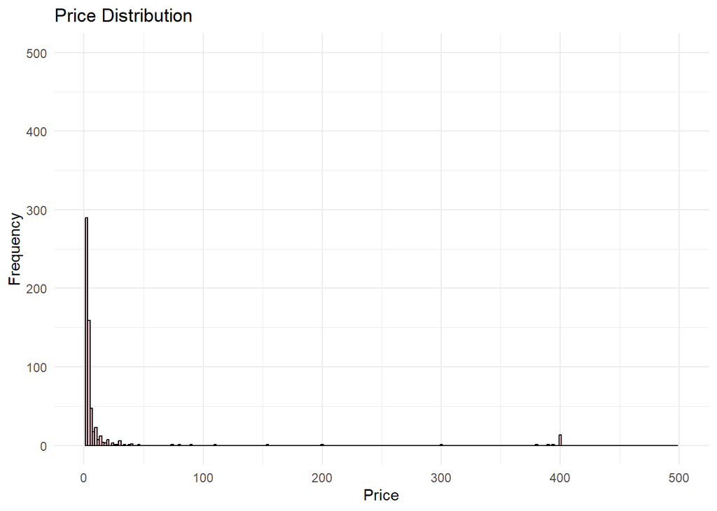

```r
# Count Plot for the Price distribution
ggplot(data_final, aes(x=Price)) +
  geom_histogram(binwidth=2, fill="pink", color="black") +
   xlim(0, 500) + ylim(0, 500) +
  labs(title="Price Distribution", x="Price", y="Frequency") +
  theme_minimal()
```

The data is highly skewed as there are many zero price entries.

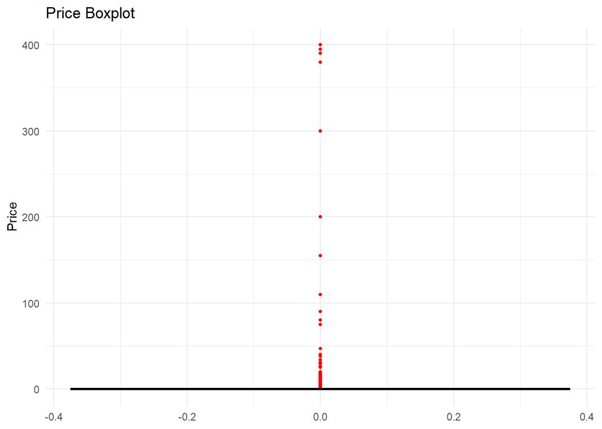

```r
# Boxplot for the same
ggplot(data_final, aes(y=Price)) +
  geom_boxplot(outlier.colour = "red", outlier.shape = 16, outlier.size = 1, fill="pink", color="black") +
  labs(title="Price Boxplot", y="Price") +
  theme_minimal()
```

#### Checking outliers for Price

```r
outlierKD2 <- function(df, var, rm = FALSE, boxplt = FALSE, histogram = TRUE, qqplt = FALSE) {
  dt <- df  # Duplicate the dataframe for potential alteration
  var_name <- eval(substitute(var), eval(dt))
  na1 <- sum(is.na(var_name))
  m1 <- mean(var_name, na.rm = TRUE)
  colTotal <- boxplt + histogram + qqplt  # Calculate the total number of charts to be displayed
  par(mfrow = c(2, max(2, colTotal)), oma = c(0, 0, 3, 0))  # Adjust layout for plots

  # Q-Q plot with custom title
  if (qqplt) {
    qqnorm(var_name, main="Q-Q plot without Outliers")
    qqline(var_name)
  }

  # Histogram with custom title
  if (histogram) {
    hist(var_name,main = "Histogram without Outliers", xlab = NA, ylab = NA)
  }

  # Box plot with custom title
  if (boxplt) {
    boxplot(var_name, main= "Box Plot without Outliers")
  }

  # Identify outliers
  outlier <- boxplot.stats(var_name)$out
  mo <- mean(outlier)
  var_name <- ifelse(var_name %in% outlier, NA, var_name)

  # Q-Q plot without outliers
  if (qqplt) {
    qqnorm(var_name, main="Q-Q plot with Outliers")
    qqline(var_name)
  }

  # Histogram without outliers
  if (histogram) {
    hist(var_name, main = "Histogram with Outliers", xlab = NA, ylab = NA)
  }

  # Box plot without outliers
  if (boxplt) {
    boxplot(var_name, main = "Boxplot with Outliers")
  }

  # Add the title for the overall plot section if any plots are displayed
  if (colTotal > 0) {
    title("Outlier Check", outer = TRUE)
    na2 <- sum(is.na(var_name))
    cat("Outliers identified:", na2 - na1, "\n")
    cat("Proportion (%) of outliers:", round((na2 - na1) / sum(!is.na(var_name)) * 100, 1), "\n")
    cat("Mean of the outliers:", round(mo, 2), "\n")
    cat("Mean without removing outliers:", round(m1, 2), "\n")
    cat("Mean if we remove outliers:", round(mean(var_name, na.rm = TRUE), 2), "\n")
  }
}
```

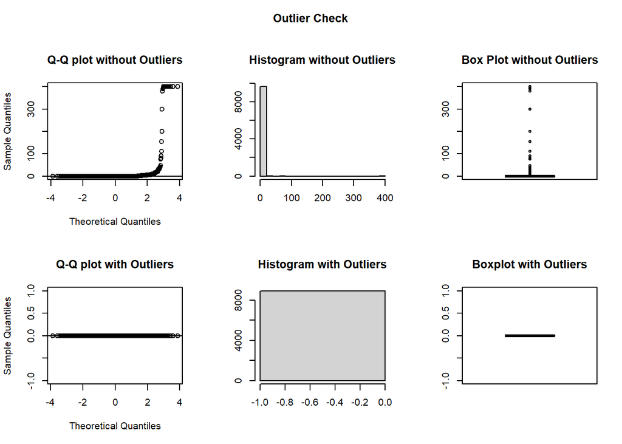

```
## Outliers identified: 756
## Proportion (%) of outliers: 8.5
## Mean of the outliers: 14.05
## Mean without removing outliers: 1.1
## Mean if we remove outliers: 0
```

```r
#outlier function is defined in previous chunck of code.
outlier_check_price = outlierKD2(data_final, Price, rm = FALSE, boxplt = TRUE, qqplt = TRUE)
```

The price values in the dataset, including both typical and extreme values, are valid observations for our analysis. As such, removing these outliers may not be beneficial for our study.

```r
#To check the value ranges
table(data_final$Price)
```

```
##
##      0   0.99      1   1.04    1.2   1.26   1.29   1.49    1.5   1.59   1.61
##   8903    145      3      1      1      1      1     46      1      1      1
##    1.7   1.75   1.76   1.96   1.97   1.99      2   2.49    2.5   2.56   2.59
##      2      1      1      1      1     73      3     25      1      1      1
##    2.6    2.9   2.95   2.99   3.02   3.04   3.08   3.28   3.49   3.61   3.88
##      1      1      1    124      1      1      1      1      7      1      1
##    3.9   3.95   3.99   4.29   4.49   4.59    4.6   4.77    4.8   4.84   4.85
##      1      1     57      1      9      1      1      1      1      1      1
##   4.99      5   5.49   5.99   6.49   6.99   7.49   7.99   8.49   8.99      9
##     70      1      5     26      5     11      2      7      2      5      1
##   9.99     10  10.99  11.99  12.99  13.99     14  14.99  15.46  15.99  16.99
##     19      2      2      3      4      2      1      9      1      1      2
##  17.99  18.99   19.4   19.9  19.99  24.99  25.99  28.99  29.99  30.99  33.99
##      2      1      1      1      5      3      1      1      5      1      1
##  37.99  39.99  46.99  74.99  79.99  89.99 109.99 154.99    200 299.99 379.99
##      1      2      1      1      1      1      1      1      1      1      1
## 389.99 394.99 399.99    400
##      1      1     12      1
```

As aldready mentioned, there are 8903 free apps (More apps with price as 0).

#### Visualization for Type Distribution

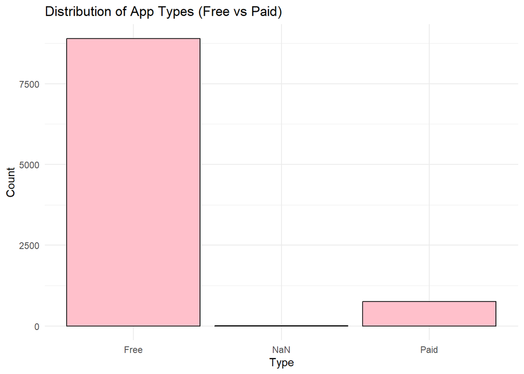

```r
# Bar Plot for the Type Distribution
ggplot(data_final, aes(x = Type)) +
  geom_bar(fill = "pink", color = "black") +
  labs(title = "Distribution of App Types (Free vs Paid)", x = "Type", y = "Count") +
  theme_minimal()
```

As it is clear, there are more free apps.

```r
#Display statistics for the Price of apps grouped by their Type
data_final$Type <- as.factor(data_final$Type)


summary_by_type <- data.frame(
  Type = levels(data_final$Type),
  Min_Price = tapply(data_clean$Price, data_clean$Type, min, na.rm = TRUE),
  Max_Price = tapply(data_clean$Price, data_clean$Type, max, na.rm = TRUE),
  Mean_Price = tapply(data_clean$Price, data_clean$Type, mean, na.rm = TRUE),
  Median_Price = tapply(data_clean$Price, data_clean$Type, median, na.rm = TRUE)
)


print(summary_by_type)
```

```
##      Type Min_Price Max_Price Mean_Price Median_Price
## Free Free      0.00         0    0.00000         0.00
## NaN   NaN      0.00         0    0.00000         0.00
## Paid Paid      0.99       400   14.04515         2.99
```

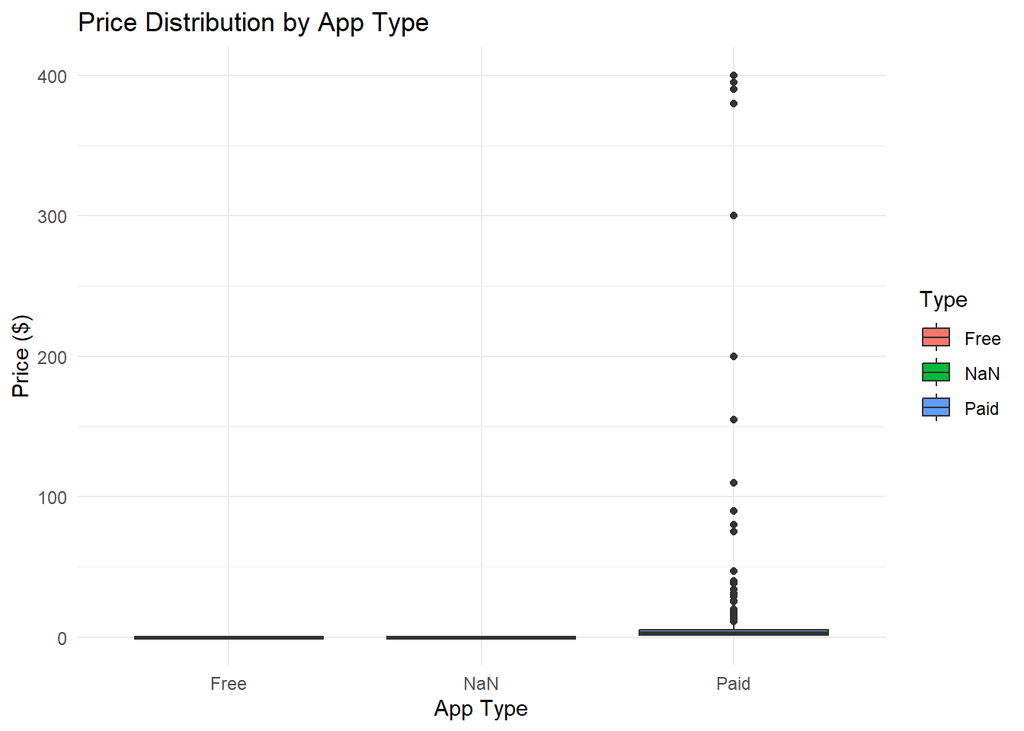

```r
#Scatter plot for price distribution by app type
ggplot(data_final, aes(x = Type, y = Price, fill = Type)) +
  geom_boxplot() +
  labs(title = "Price Distribution by App Type",
       x = "App Type",
       y = "Price ($)") +
  theme_minimal()
```

#### Histogram for price distribution by App Type

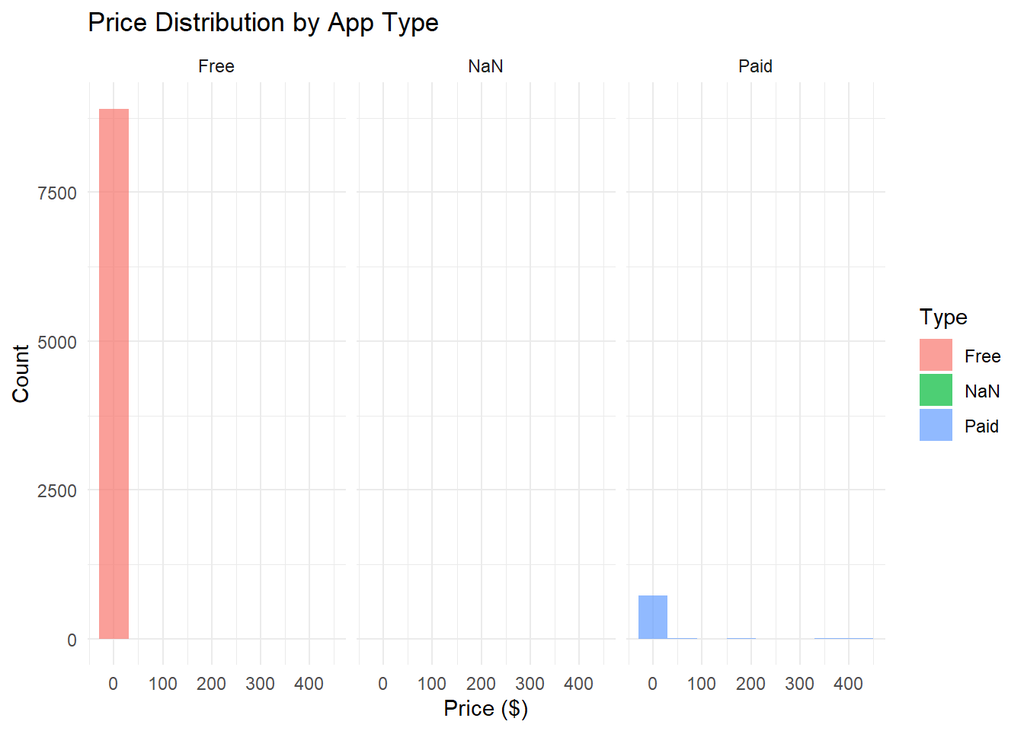

```r
ggplot(data_final, aes(x = Price, fill = Type)) +
  geom_histogram(binwidth = 60, alpha = 0.7, position = "identity") +
  facet_wrap(~ Type) +
  labs(title = "Price Distribution by App Type",
       x = "Price ($)",
       y = "Count") +
  theme_minimal()
```

Upon analyzing the price distribution across different app types, we found that some values in the Type column do not accurately represent the app prices (from above plot). Since we can fully rely on the Price values for our analysis, the Type column is seemed unnecessary.

Hence, Removing the Type column…

#### Dropping the Type column

```r
#Using subset function
data_final <- subset(data_final, select = -Type)
```

```r
#After removing the Type column and duplicated values
str(data_final)
```

```
## 'data.frame':    9659 obs. of  10 variables:
##  $ App           : chr  "Photo Editor & Candy Camera & Grid & ScrapBook" "Coloring book moana" "U Launcher Lite – FREE Live Cool Themes, Hide Apps" "Sketch - Draw & Paint" ...
##  $ Category      : Factor w/ 33 levels "ART_AND_DESIGN",..: 1 1 1 1 1 1 1 1 1 1 ...
##  $ Rating        : num  4.1 3.9 4.7 4.5 4.3 4.4 3.8 4.1 4.4 4.7 ...
##  $ Reviews       : num  159 967 87510 215644 967 ...
##  $ Size          : num  19 14 8.7 25 2.8 5.6 19 29 33 3.1 ...
##  $ Installs      : num  1e+04 5e+05 5e+06 5e+07 1e+05 5e+04 5e+04 1e+06 1e+06 1e+04 ...
##  $ Price         : num  0 0 0 0 0 0 0 0 0 0 ...
##  $ Content.Rating: chr  "everyone" "everyone" "everyone" "teen" ...
##  $ Last.Updated  : Date, format: "2018-01-07" "2018-01-15" ...
##  $ Android.Ver   : Factor w/ 34 levels "1.0 and up","1.5 and up",..: 16 16 16 19 21 9 16 19 11 16 ...
```

##### The Type column is successfully removed.

Let’s do bivariate analysis on price and other variables starting from here.

#### Visualization for Price vs Installs

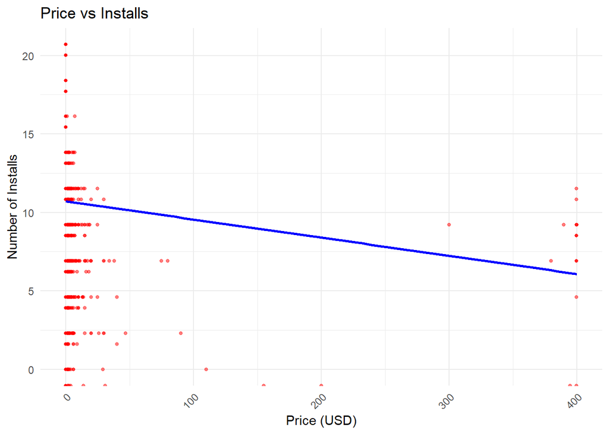

```r
#Plotting a scatter plot between Price and installs
ggplot(data_final, aes(x=Price, y=log(data_clean$Installs))) +
  geom_point(color = 'red', size = 1, alpha = 0.5) +
  geom_smooth(method = 'lm', color = 'blue', se = FALSE) +
  labs(title = "Price vs Installs", x = "Price (USD)", y = "Number of Installs") +
  theme_minimal() +
  theme(axis.text.x = element_text(angle = 45, hjust = 1))
```

From the scatter plot, we can see that there are more number of installations with price value 0.

```r
# Categorize the apps as "Free" or "Paid" based on Price
Price_Category <- ifelse(data_final$Price == 0, "Free", "Paid")
str(data_final$Price)
```

```
##  num [1:9659] 0 0 0 0 0 0 0 0 0 0 ...
```

```r
str(Price_Category)
```

```
##  chr [1:9659] "Free" "Free" "Free" "Free" "Free" "Free" "Free" "Free" ...
```

```r
#str(log(data_clean$Installs))
```

For a better visualization, we are categorizing price values 0 as free apps and plotting abox plot.

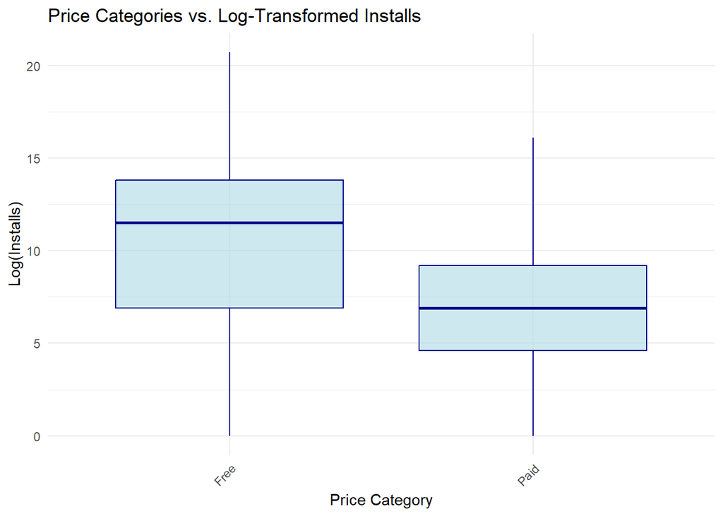

```r
# Box plot of Price Category vs. log-transformed Installs
ggplot(data_final, aes(x = Price_Category, y = log(data_clean$Installs))) +
  geom_boxplot(fill = "lightblue", color = "darkblue", alpha = 0.6) +
  labs(title = "Price Categories vs. Log-Transformed Installs",
       x = "Price Category",
       y = "Log(Installs)") +
  theme_minimal() +
  theme(axis.text.x = element_text(angle = 45, hjust = 1))
```

```r
# Categorize the apps as "Free" or "Paid" based on Price
Price_Category <- ifelse(data_final$Price == 0, "Free", "Paid")
str(data_final$Price)
```

```
##  num [1:9659] 0 0 0 0 0 0 0 0 0 0 ...
```

```r
str(Price_Category)
```

```
##  chr [1:9659] "Free" "Free" "Free" "Free" "Free" "Free" "Free" "Free" ...
```

```r
#str(data_final$log(data_clean$Installs))

table(Price_Category)
```

```
## Price_Category
## Free Paid
## 8903  756
```

```r
# Add Price_Category to data_final
data_duplicate <- data_final
data_duplicate$Price_Category <- ifelse(data_final$Price == 0, "Free", "Paid")

# Create a summarized table for Price_Category and log_Installs
summary_table <- data_duplicate %>%
  group_by(Price_Category) %>%
  summarise(Average_Log_Installs = mean(log(data_clean$Installs), na.rm = TRUE),
            Count = n())

# View the summarized table
kable(summary_table, format = "html", col.names = c("Price Category", "Mean Log(Installs)", "App Count")) %>%
  kable_styling(full_width = FALSE, position = "center")
```

| Price Category | Mean Log(Installs) | App Count |
| --- | --- | --- |
| Free | -Inf | 8903 |
| Paid | -Inf | 756 |

#### Visualization for Price vs Reviews & Rating

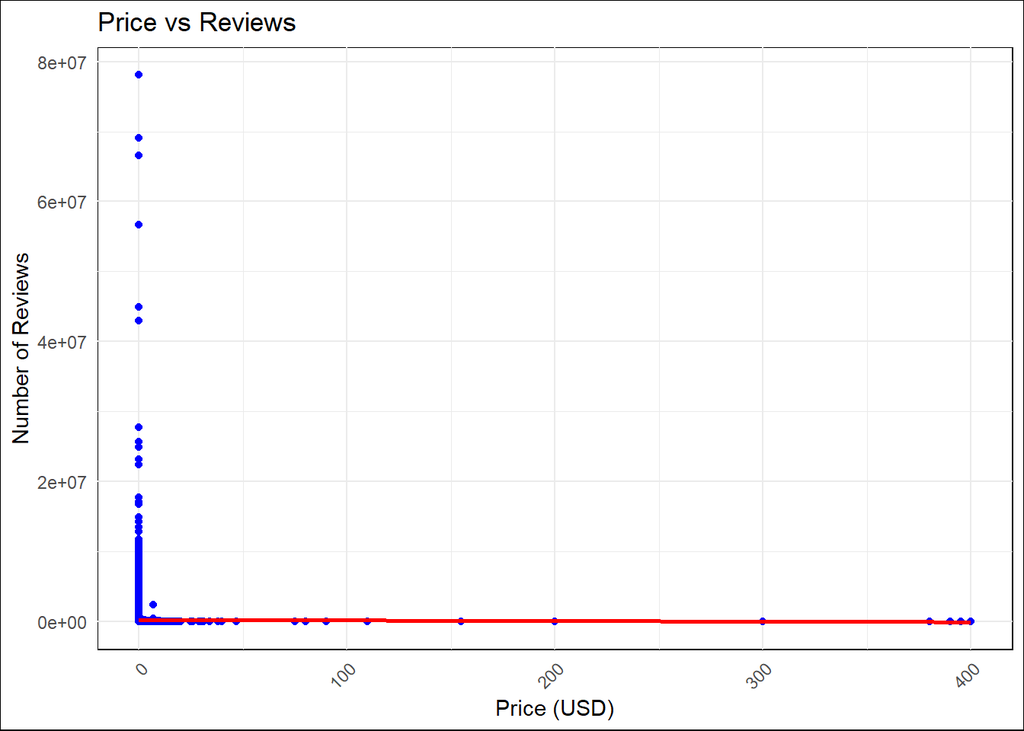

```r
# Plot Price vs. Reviews
ggplot(data_final, aes(x=Price, y=Reviews)) +
  geom_point(color = 'blue') +
  geom_smooth(method = 'lm', color = 'red', se = FALSE) +
  labs(title = "Price vs Reviews", x = "Price (USD)", y = "Number of Reviews") +
  theme_minimal() +
  theme(
    panel.background = element_rect(fill = "white"),  # Set panel background to white
    plot.background = element_rect(fill = "white"),   # Set plot background to white
    axis.text.x = element_text(angle = 45, hjust = 1)
  )
```

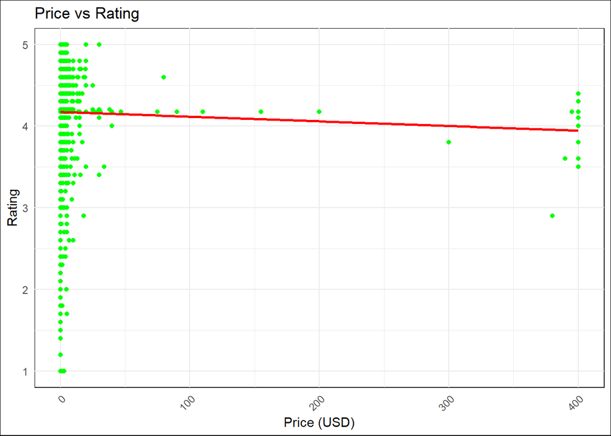

```r
# Plot Price vs. Rating
ggplot(data_final, aes(x=Price, y=Rating)) +
  geom_point(color = 'green') +
  geom_smooth(method = 'lm', color = 'red', se = FALSE) +
  labs(title = "Price vs Rating", x = "Price (USD)", y = "Rating") +
  theme_minimal() +
  theme(
    panel.background = element_rect(fill = "white"),  # Set panel background to white
    plot.background = element_rect(fill = "white"),   # Set plot background to white
    axis.text.x = element_text(angle = 45, hjust = 1)
  )
```

Price vs Reviews with installation: Cheaper products tend to have more reviews, indicating higher popularity or more frequent purchases. In contrast, expensive products tend to have fewer reviews, possibly because fewer people buy higher-priced items.

Price vs Ratings with installation: Price does not strongly affect the average rating, but there is a slight trend where lower-priced products have more variation in ratings, while higher-priced products tend to receive more consistent ratings around 4. May be higher price apps are meeting the customer expectations.

#### Visualization for Price vs Reviews vs Installs

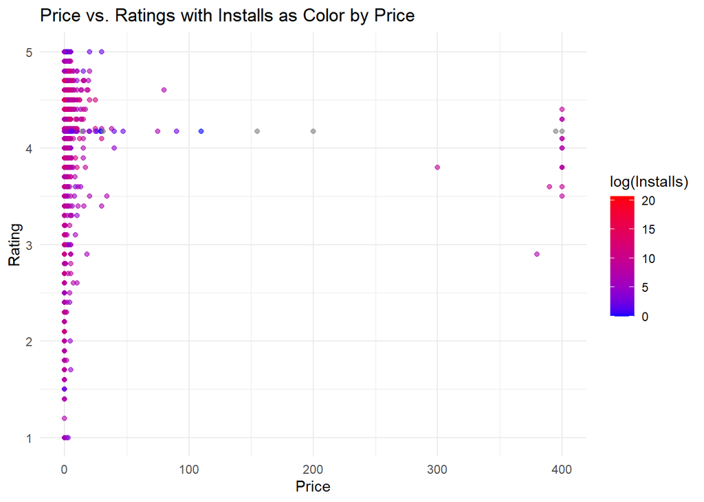

```r
# Scatter plot of Price vs. Ratings with log_Installs as  color
ggplot(data_final, aes(x = Price, y = Rating,color = log(data_clean$Installs))) +
  geom_point(alpha = 0.6) +
  scale_color_gradient(low = "blue", high = "red") +
  labs(title = "Price vs. Ratings with Installs as Color by Price",
       x = "Price",
       y = "Rating",
       color = "log(Installs)") +
  theme_minimal()
```

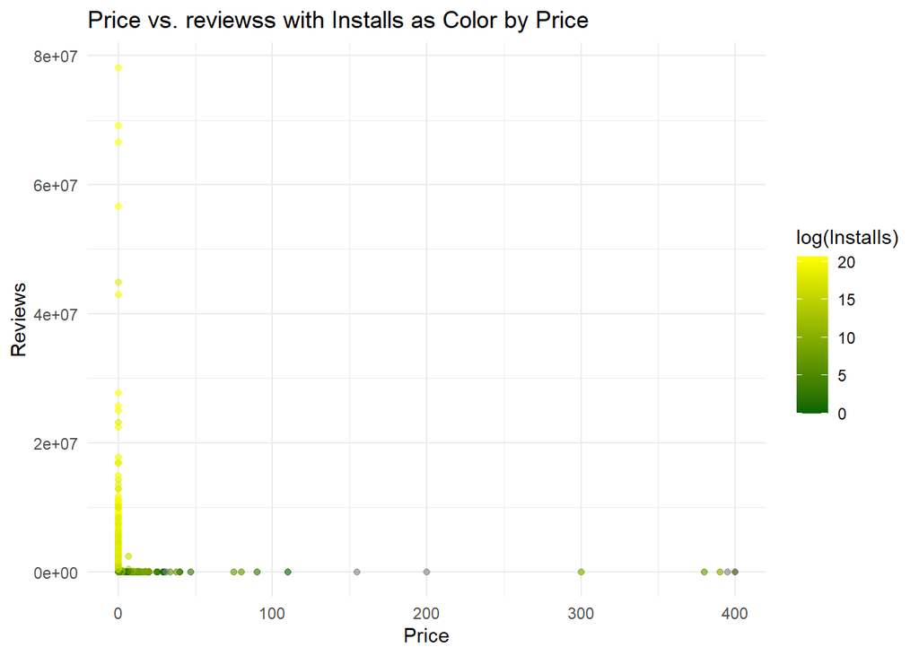

```r
# Scatter plot of Price vs. Reviews with log_Installs as color
ggplot(data_final, aes(x = Price, y = Reviews,color = log(data_clean$Installs))) +
  geom_point(alpha = 0.6) +
  scale_color_gradient(low = "darkgreen", high = "yellow") +
  labs(title = "Price vs. reviewss with Installs as Color by Price",
       x = "Price",
       y = "Reviews",
       color = "log(Installs)") +
  theme_minimal()
```

Concluding: Apps with lower prices, have more ratings and installs while apps priced higher tend to have fewer installs and more scattered ratings. Similarly, for reviews.

#### Visualization for Price vs Size

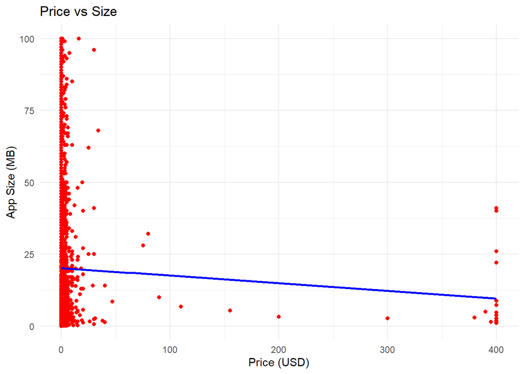

```r
# Plot Price vs Size
ggplot(data_final, aes(x=Price, y=Size)) +
  geom_point(color = 'red') +
  geom_smooth(method = 'lm', color = 'blue', se = FALSE) +
  labs(title = "Price vs Size", x = "Price (USD)", y = "App Size (MB)") +
  theme_minimal()
```

#### Visulization for Distribution of Installs

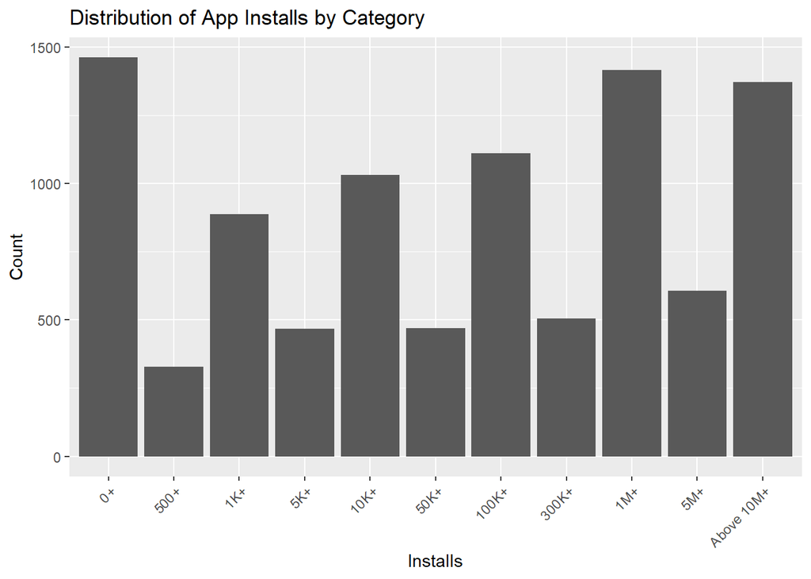

```r
# Create a new data frame to store the factor levels
data_clean1_factor <- data_final  # Assuming you want to keep the original data intact
data_clean1_factor$Installs <- factor(data_final$Installs, levels = sorted_values)
# Define new breaks for more even intervals for Installs
install_breaks <- c(c(0, 500, 1000, 5000, 10000, 50000, 100000, 300000, 1000000, 5000000,10000000, Inf))

# Create a categorical variable for installs based on these breaks
data_clean1_factor$Installs_Category <- cut(
  as.numeric(as.character(data_final$Installs)),
  breaks = install_breaks,
  right = FALSE,
  labels = c("0+", "500+", "1K+", "5K+", "10K+", "50K+", "100K+", "300K+", "1M+", "5M+","Above 10M+")
)


# Plot the categorized Installs data
library(ggplot2)
ggplot(data_clean1_factor, aes(x = Installs_Category)) +
  geom_bar() +
  xlab("Installs") +
  ylab("Count") +
  theme(axis.text.x = element_text(angle = 45, hjust = 1)) +
  ggtitle("Distribution of App Installs by Category")
```

#### Installs vs Size

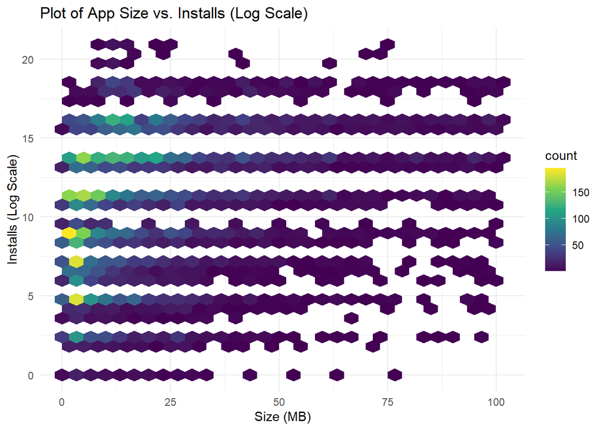

```r
ggplot(data_clean, aes(x = Size, y = log(Installs))) +
  geom_hex(bins = 30) +
  scale_fill_viridis_c() + # Adds color gradient
  labs(title = "Plot of App Size vs. Installs (Log Scale)",
       x = "Size (MB)",
       y = "Installs (Log Scale)") +
  theme_minimal()
```

### Visualization for Rating Distribution

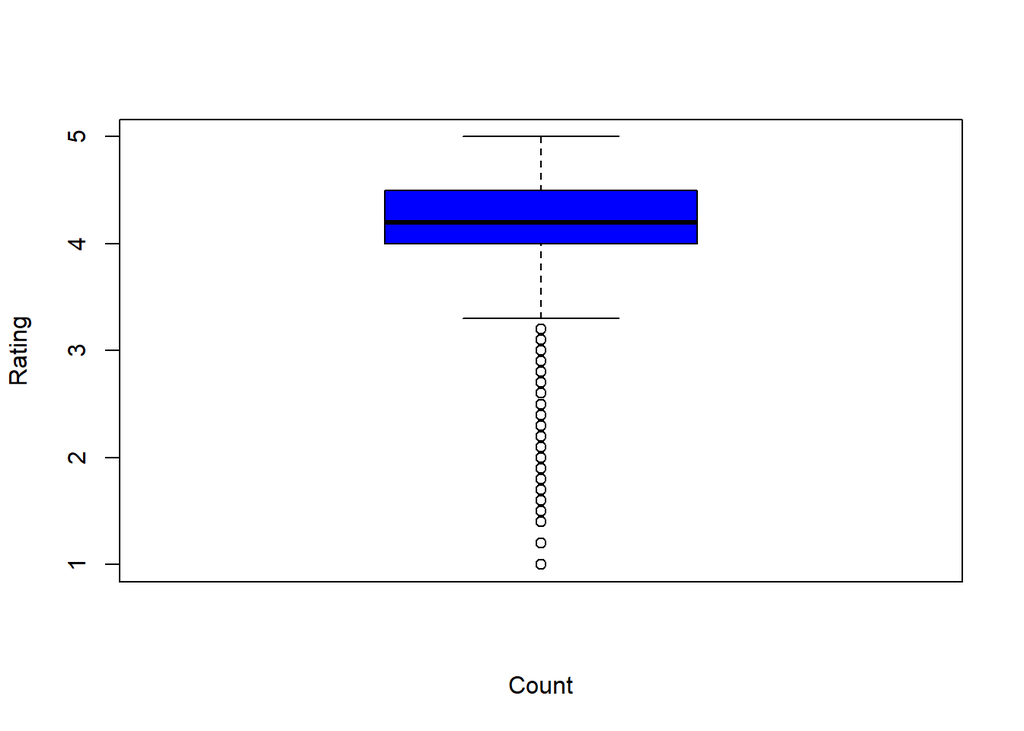

```r
boxplot(data_final$Rating,ylab = "Rating", xlab = "Count",col = "Blue")
```

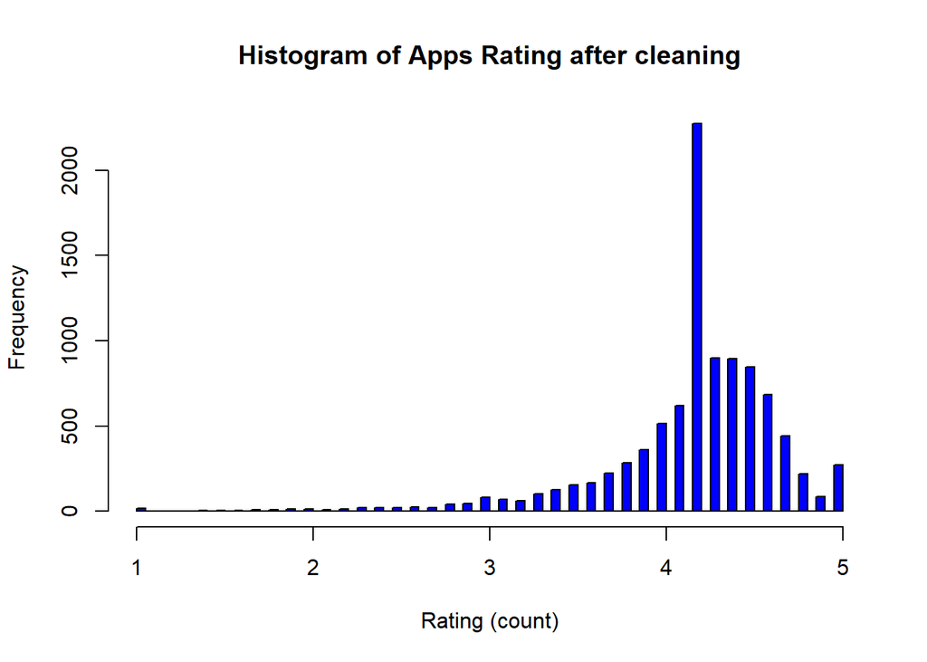

```r
hist(data_clean$Rating, main="Histogram of Apps Rating after cleaning", xlab="Rating (count)", col = 'blue', breaks = 100 )
```

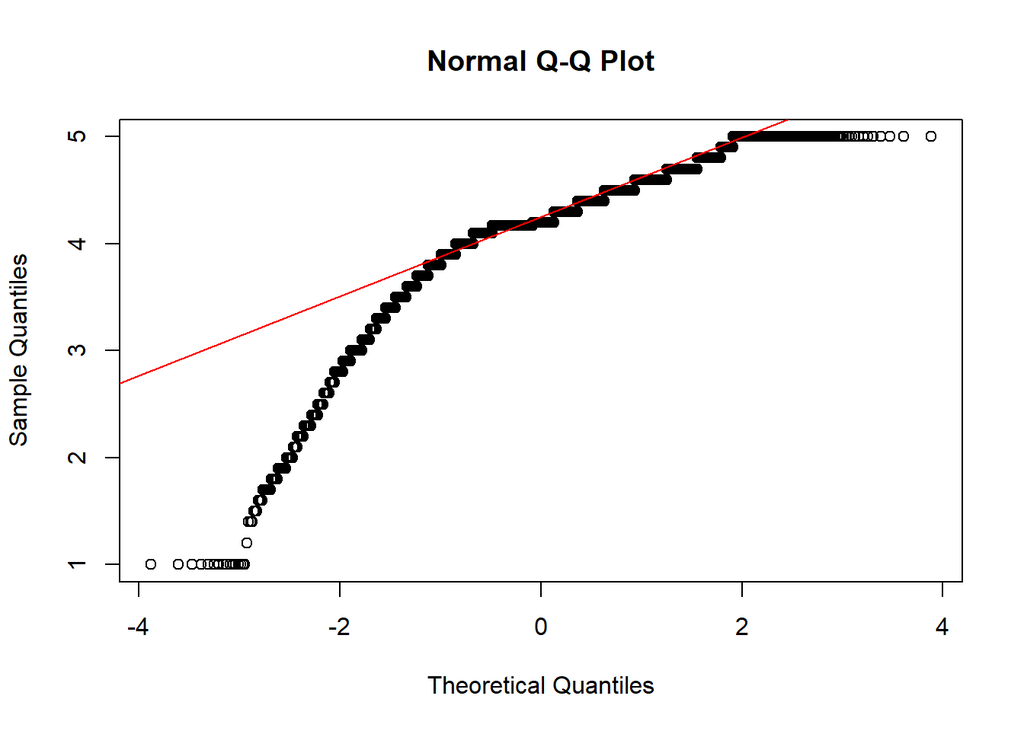

```r
qqnorm(data_clean$Rating)
qqline(data_clean$Rating, col = "red")
```

Here, it could be seen the plots are much clearer but still skewed due to other outliers from 1-3 rating but as these may be the reason from which we could find why the apps are low rated hencecannot be removed from our dataset.

### Visualization for Reviews

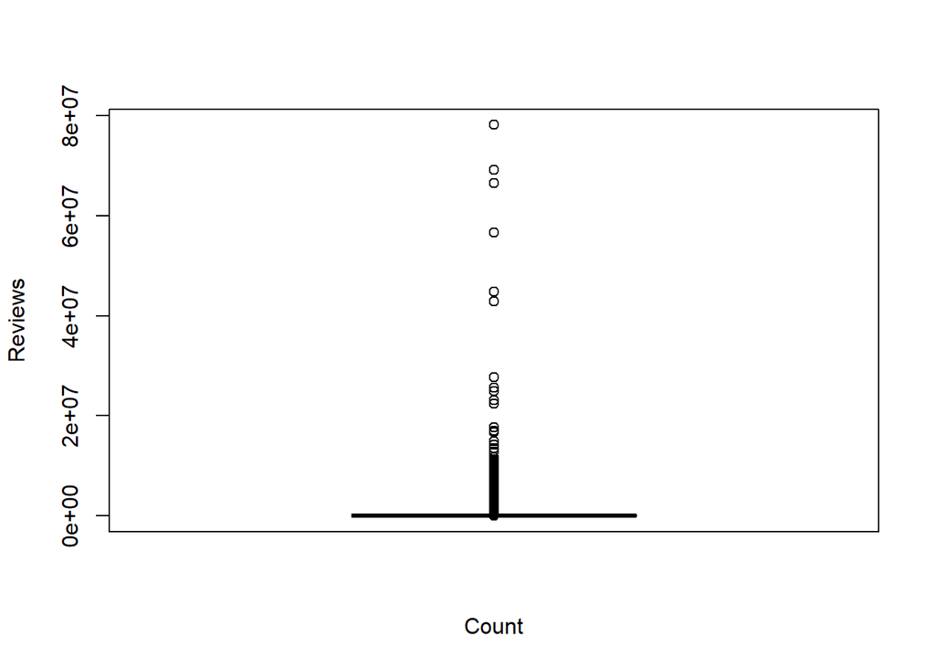

```r
boxplot(data_final$Reviews,ylab = "Reviews", xlab = "Count",col = 'Blue')
```

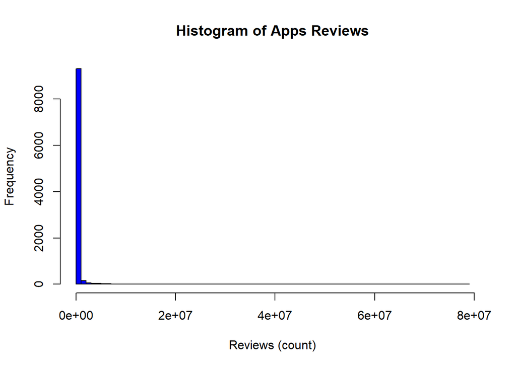

```r
hist(data_final$Reviews, main="Histogram of Apps Reviews", xlab="Reviews (count)", col = 'blue', breaks = 100 )
```

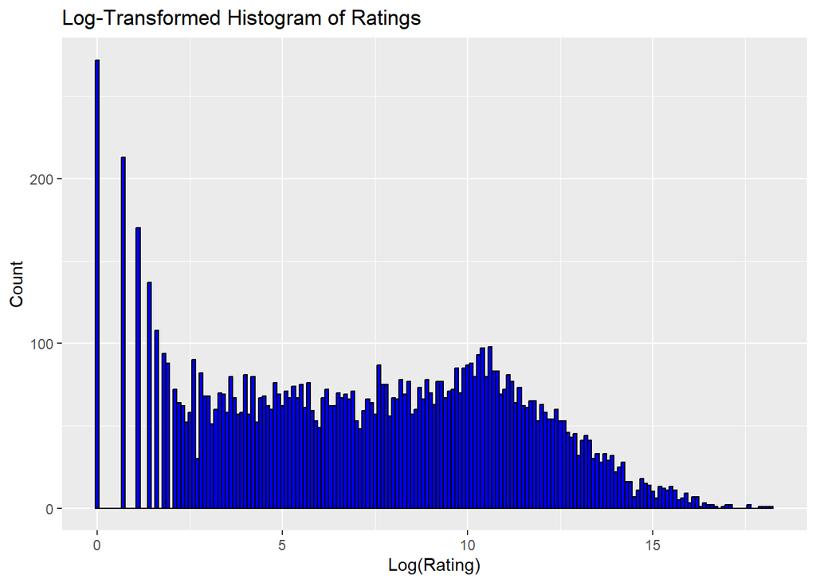

```r
ggplot(data_final, aes(x = log(Reviews))) +
  geom_histogram(binwidth = 0.1, fill = "blue", color = "black") +
  labs(title = "Log-Transformed Histogram of Ratings", x = "Log(Rating)", y = "Count")
```

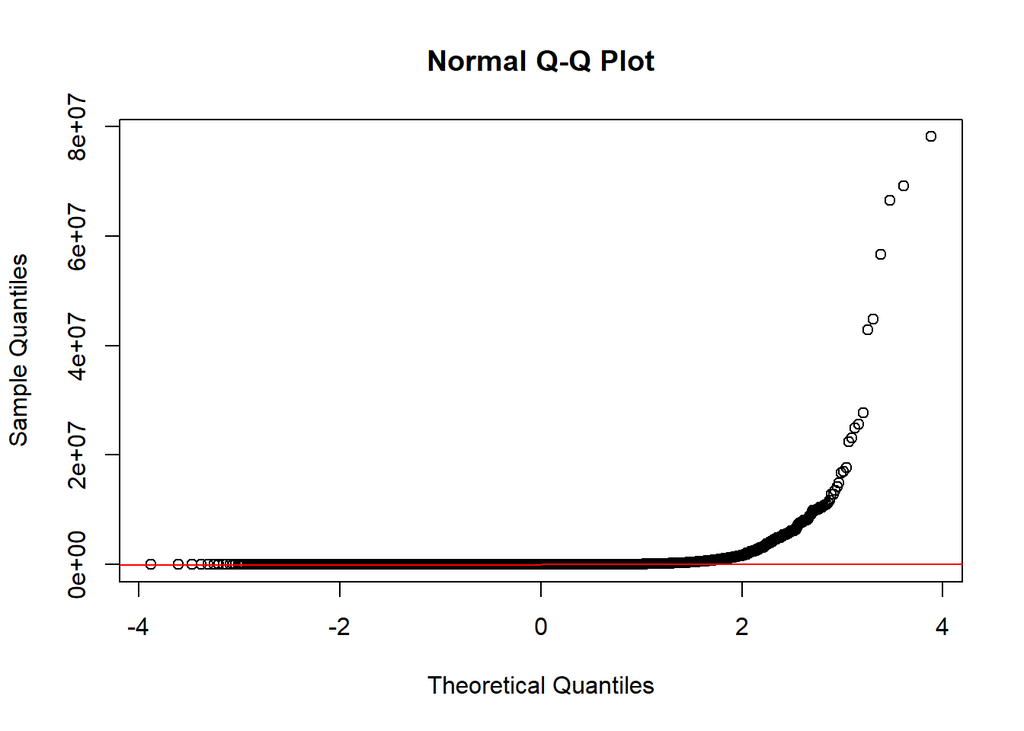

```r
qqnorm(data_final$Reviews)
qqline(data_final$Reviews, col = "red")
```

Similar to the case of ratings the plots are skewed due to the outliers. Hence, we can use the log plot of reviews for the visualisation which is normalised version of Reviews. As they are skewed, they donot follow normal distribution.

#### Review frequency table

```r
xkablesummary(data_final)
```

Table: Statistics summary.

|  | App | Category | Rating | Reviews | Size | Installs | Price | Content.Rating | Last.Updated | Android.Ver |
| --- | --- | --- | --- | --- | --- | --- | --- | --- | --- | --- |
| Min | Length:9659 | FAMILY :1832 | Min. :1.000 | Min. : 0 | Min. : 0.0085 | Min. :0.000e+00 | Min. : 0.000 | Length:9659 | Min. :2010-05-21 | 4.1 and up :2202 |
| Q1 | Class :character | GAME : 959 | 1st Qu.:4.000 | 1st Qu.: 25 | 1st Qu.: 5.3000 | 1st Qu.:1.000e+03 | 1st Qu.: 0.000 | Class :character | 1st Qu.:2017-08-05 | 4.0.3 and up :1395 |
| Median | Mode :character | TOOLS : 827 | Median :4.200 | Median : 967 | Median : 13.1000 | Median :1.000e+05 | Median : 0.000 | Mode :character | Median :2018-05-04 | 4.0 and up :1285 |
| Mean | NA | BUSINESS : 420 | Mean :4.173 | Mean : 216593 | Mean : 20.1512 | Mean :7.778e+06 | Mean : 1.099 | NA | Mean :2017-10-30 | Varies with device: 990 |
| Q3 | NA | MEDICAL : 395 | 3rd Qu.:4.500 | 3rd Qu.: 29401 | 3rd Qu.: 27.0000 | 3rd Qu.:1.000e+06 | 3rd Qu.: 0.000 | NA | 3rd Qu.:2018-07-17 | 4.4 and up : 818 |
| Max | NA | PERSONALIZATION: 376 | Max. :5.000 | Max. :78158306 | Max. :100.0000 | Max. :1.000e+09 | Max. :400.000 | NA | Max. :2018-08-08 | 2.3 and up : 616 |
| NA | NA | (Other) :4850 | NA | NA | NA | NA | NA | NA | NA | (Other) :2353 |

```r
outlierKD2(data_final, Reviews)
```

```
## Outliers identified: 1656
## Proportion (%) of outliers: 20.7
## Mean of the outliers: 1228141
## Mean without removing outliers: 216592.6
## Mean if we remove outliers: 7280.61
```

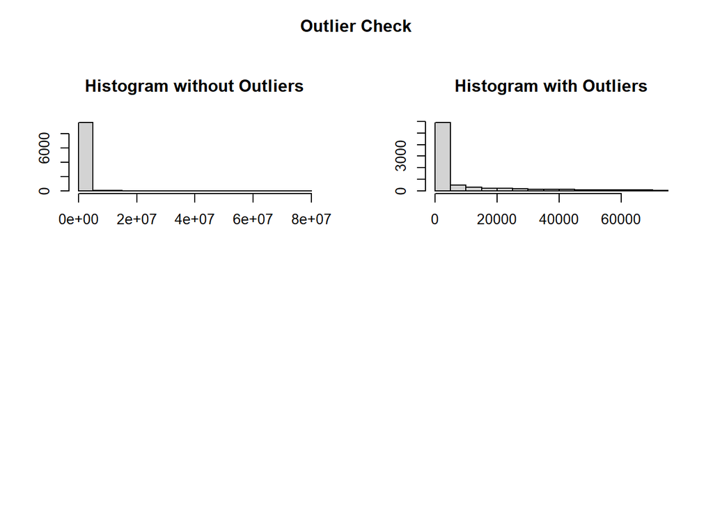

To check which are outliers lets make sections of data that is create bins to check which bins have maximum data, this would help us see how reviews are distributed.

#### Binned reviews

```r
# Define the new custom breaks for bins
# Ensure there are no NA values


# Define new breaks for more even intervals
breaks <- c(0, 100, 500, 1000, 2500, 5000, 10000, 25000,50000,100000, 300000,1000000,Inf)

# Create a categorical variable based on the new breaks
Review_Category <- cut(data_final$Reviews, breaks = breaks, right = FALSE,
                   labels = c("0+","100+", "500+", "1K+",
                              "2.5K+", "5K+", "10K+","25K+",
                              "50K+", "100K+","300K+","1M+"))

# Count the number of values in each bin
bin_counts <- as.data.frame(table(Review_Category))

# Rename the columns for clarity
colnames(bin_counts) <- c("Review_Category", "Count")

# Print the counts
print(bin_counts)
```

```
##    Review_Category Count
## 1               0+  3327
## 2             100+  1065
## 3             500+   462
## 4              1K+   586
## 5            2.5K+   475
## 6              5K+   474
## 7             10K+   719
## 8             25K+   606
## 9             50K+   498
## 10           100K+   647
## 11           300K+   451
## 12             1M+   349
```

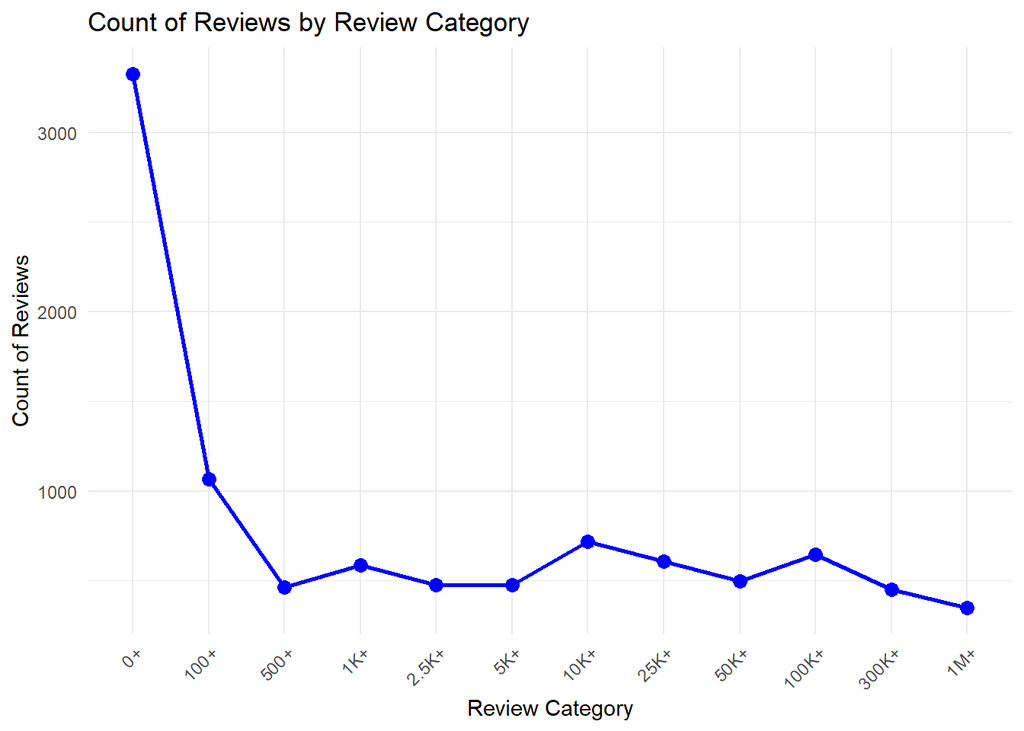

```r
# Create a line plot of the binned counts
ggplot(bin_counts, aes(x = Review_Category, y = Count, group = 1)) +
  geom_line(color = "blue", size = 1) +
  geom_point(color = "blue", size = 3) +
  labs(title = "Count of Reviews by Review Category",
       x = "Review Category",
       y = "Count of Reviews") +
  theme_minimal() +
  theme(axis.text.x = element_text(angle = 45, hjust = 1))  # Rotate x-axis labels for readability
```

Hence, high reviews can be observed in less apps and less reviews can be observed in more apps which is expected.

#### Boxplots for Rating vs Reviews

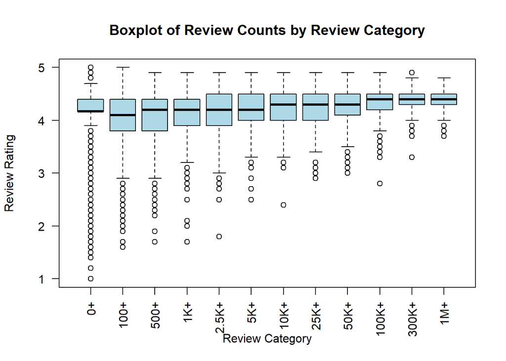

```r
boxplot( data_final$Rating~ Review_Category, data = data_clean,
        main = "Boxplot of Review Counts by Review Category",
        xlab = "Review Category",
        ylab = "Review Rating",
        las = 2,        # Rotate the x-axis labels for readability
        col = "lightblue")  # Optional: Set color for the boxplots
```

In this we could observe that, as reviews increase the median of rating increased and the values clustered around higher ratings which could show that high reviews, could mean a better rated app.

#### Mean value of Ratings for each Review bins

```r
# Calculate the mean Rating for each Review_Category
mean_ratings <- tapply(data_final$Rating, Review_Category, mean, na.rm = TRUE)

# Convert the result to a data frame for better readability
mean_ratings_df <- data.frame(Review_Category = names(mean_ratings), Mean_Rating = as.numeric(mean_ratings))

# Print the mean ratings for each review bin
print(mean_ratings_df)
```

```
##    Review_Category Mean_Rating
## 1               0+    4.126221
## 2             100+    4.029538
## 3             500+    4.063188
## 4              1K+    4.107030
## 5            2.5K+    4.129572
## 6              5K+    4.191139
## 7             10K+    4.221836
## 8             25K+    4.231848
## 9             50K+    4.293775
## 10           100K+    4.329830
## 11           300K+    4.375610
## 12             1M+    4.426361
```

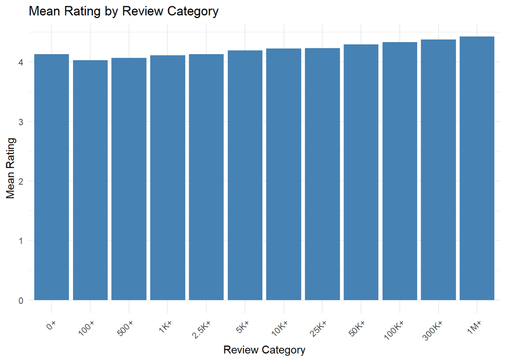

```r
# Define correct order of Review_Category as a factor
mean_ratings_df$Review_Category <- factor(mean_ratings_df$Review_Category,
                                          levels = c("0+","100+", "500+", "1K+",
                                                     "2.5K+", "5K+", "10K+","25K+",
                                                     "50K+", "100K+", "300K+", "1M+"))

# Plot the mean ratings for each review bin in the correct order
ggplot(mean_ratings_df, aes(x = Review_Category, y = Mean_Rating)) +
  geom_bar(stat = "identity", fill = "steelblue") +  # Use bar plot
  labs(title = "Mean Rating by Review Category",
       x = "Review Category",
       y = "Mean Rating") +
  theme_minimal() +
  theme(axis.text.x = element_text(angle = 45, hjust = 1))  # Rotate x-axis labels for readability
```

As we can see, the mean rating increases as the reviews increase.

#### Histogram for Reviews and Rating

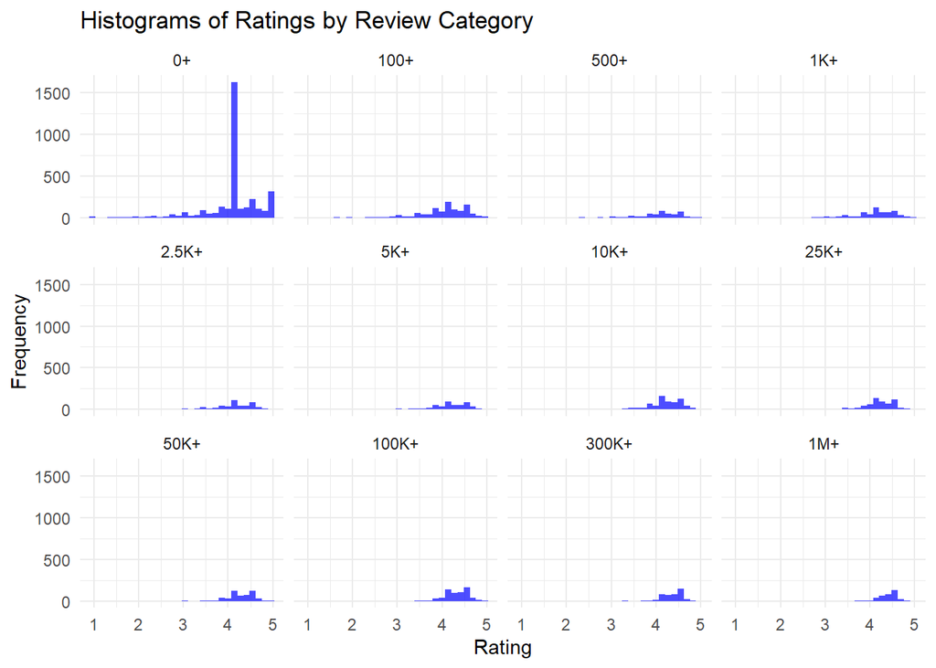

```r
# Create a new data frame for plotting
plot_data <- data.frame(Rating = data_final$Rating, Review_Category = Review_Category)

# Create a histogram of Ratings, faceted by Review_Category
ggplot(plot_data, aes(x = Rating)) +
  geom_histogram(bins = 30, fill = "blue", alpha = 0.7) +
  facet_wrap(~ Review_Category, labeller = label_wrap_gen()) +  # Facet by Review_Category
  theme_minimal() +
  labs(title = "Histograms of Ratings by Review Category", x = "Rating", y = "Frequency")
```

This is another representation of ratings vs reviews.

#### Visualization for Reviews vs Installs

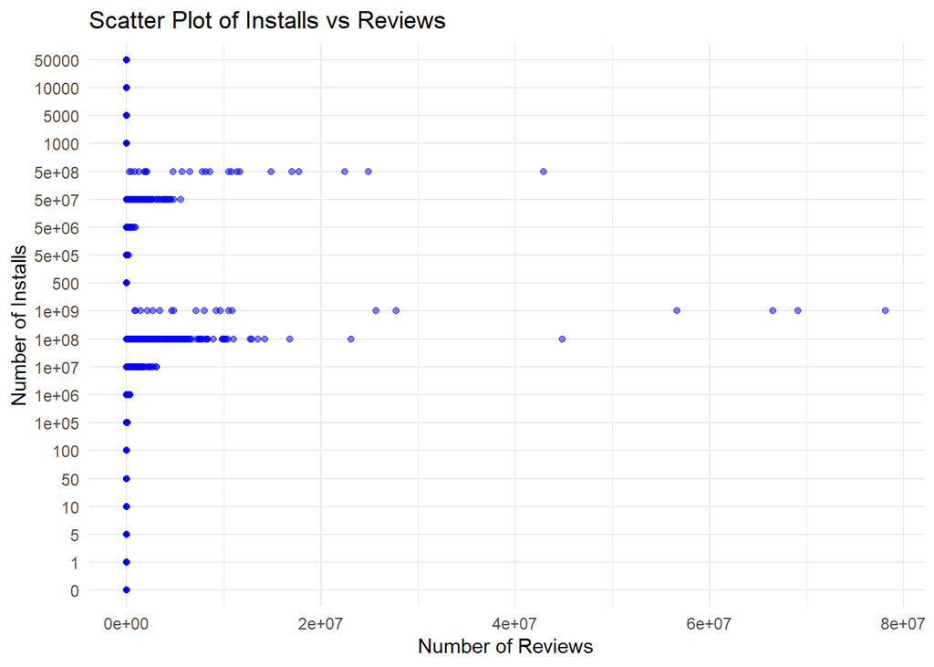

```r
# Scatter plot for Installs vs Reviews
ggplot(data_clean1_factor, aes(x = Reviews, y = Installs)) +
  geom_point(color = "blue", alpha = 0.5) +
  labs(title = "Scatter Plot of Installs vs Reviews",
       x = "Number of Reviews",
       y = "Number of Installs") +
  theme_minimal()
```

#### Visualization for Rating vs Installs

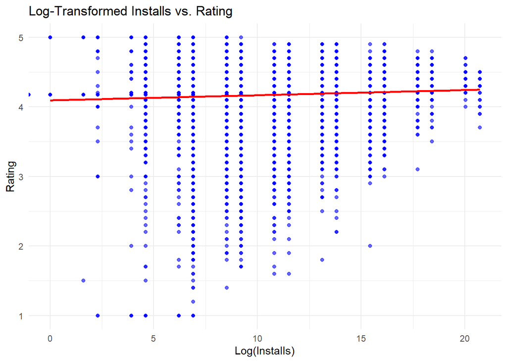

```r
# Scatter plot of log-transformed Installs vs. Rating
ggplot(data_final, aes(x = log(data_clean$Installs), y = Rating)) +
  geom_point(color = "blue", alpha = 0.6) +
  geom_smooth(method = "lm", color = "red", se = FALSE) +  # Add a regression line
  labs(title = "Log-Transformed Installs vs. Rating",
       x = "Log(Installs)",
       y = "Rating") +
  theme_minimal()
```

#### Visualization for Rating vs Installs by Category

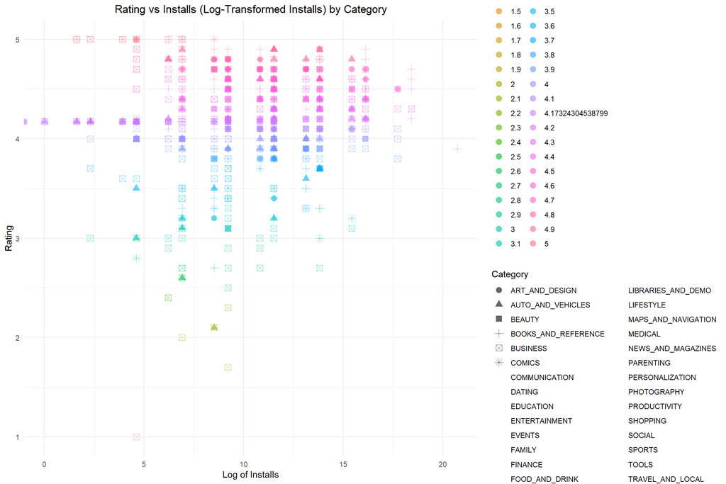

#### Visualization for Category Distribution

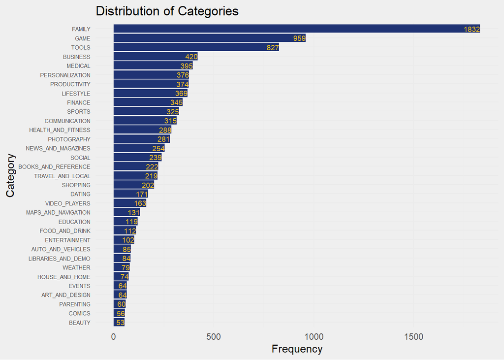

```r
category_counts <- table(data_final$Category)

# Convert to data frame for plotting
category_counts_df <- as.data.frame(category_counts)
colnames(category_counts_df) <- c("Category", "Frequency")

ggplot(category_counts_df, aes(x = reorder(Category, Frequency), y = Frequency)) +
  geom_bar(stat = "identity", fill = "#1f3374") +
  geom_text(aes(label = Frequency), vjust = 0.5, hjust=1, size=2.5, color='#f8c220') +
  coord_flip() +
  labs(title = "Distribution of Categories", x = "Category", y = "Frequency") +
  theme_minimal() +
   theme(
    plot.background = element_rect(fill = "#efefef", color = NA),
    panel.background = element_rect(fill = "#efefef", color = NA),
    axis.text.y = element_text(size = 5.5)
  )
```

AS it can be seen from the graph above, most of the apps in the dataset belong to the Family category, and Beauty has the least number of apps.

#### Visualization for Category vs. Installs

Below is a boxplot show the distribution of number of installs for each category order by mean from highest to lowest.

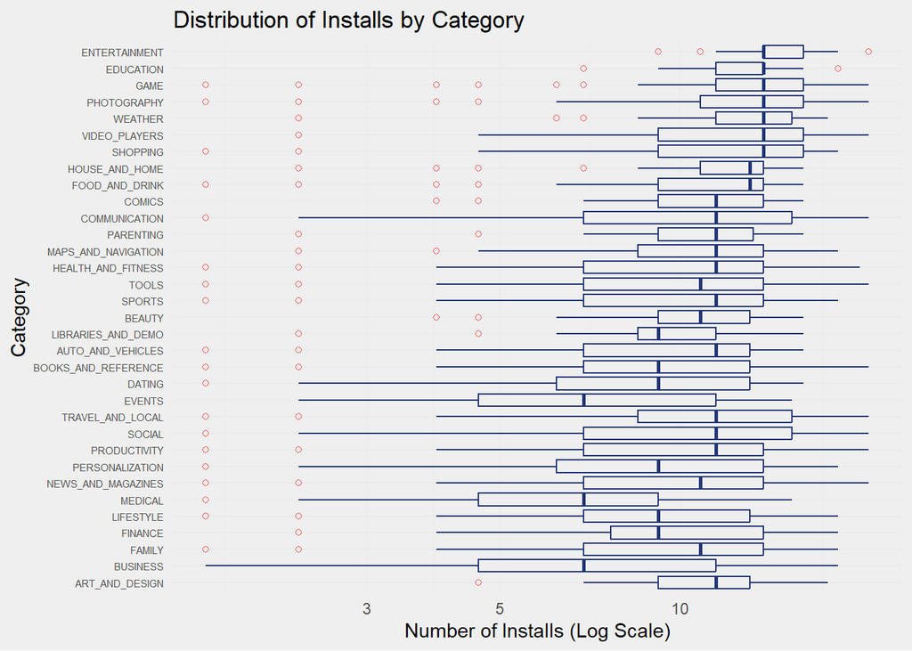

```r
ggplot(data_clean, aes(x = reorder(Category, log(data_final$Installs),  FUN = mean), y = log(data_clean$Installs))) +
  geom_boxplot(outlier.color = "#f05555", outlier.shape = 1, color='#1f3374', fill="#efefef") +  # Red outliers for emphasis
  coord_flip() +  # Flip for better readability
  scale_y_log10() +
  theme_minimal() +
  labs(title = "Distribution of Installs by Category",
       x = "Category",
       y = "Number of Installs (Log Scale)") +
    theme(
    plot.background = element_rect(fill = "#efefef", color = NA),
    panel.background = element_rect(fill = "#efefef", color = NA),
    axis.text.y = element_text(size = 5.5)
  )
```